# Assignment 1

```r
stepsAvg2 <- mean(clean2$steps)
stepsMedian2 <- median(clean2$steps)

data.frame(stepsAvg, stepsAvg2, stepsMedian, stepsMedian2)
```

```
##   stepsAvg stepsAvg2 stepsMedian stepsMedian2
## 1 10766.19  10766.19       10765        10765
```

Next, using dplyr, we can add another column indicating whether the day is a weekday or a weekend. Thus, is possible to stablish differences between them.

```r
days <- clean%>%
            mutate(Day = weekdays(clean$date))


weeknd <- c("sábado", "domingo")

for(i in 1:length(days$Day)){
      if(days$Day[i] %in% weeknd){days$Day[i] <- "weekend"}else{days$Day[i] <- "weekday"}
     }
```

```r
interval2 <- days%>%
            group_by(interval, Day)%>%
            summarise(steps = mean(steps))%>%
      print()
```

```
## Source: local data frame [576 x 3]
## Groups: interval
##
##    interval     Day     steps
## 1         0 weekday 2.3333333
## 2         0 weekend 0.0000000
## 3         5 weekday 0.4615385
## 4         5 weekend 0.0000000
## 5        10 weekday 0.1794872
## 6        10 weekend 0.0000000
## 7        15 weekday 0.2051282
## 8        15 weekend 0.0000000
## 9        20 weekday 0.1025641
## 10       20 weekend 0.0000000
## ..      ...     ...       ...
```

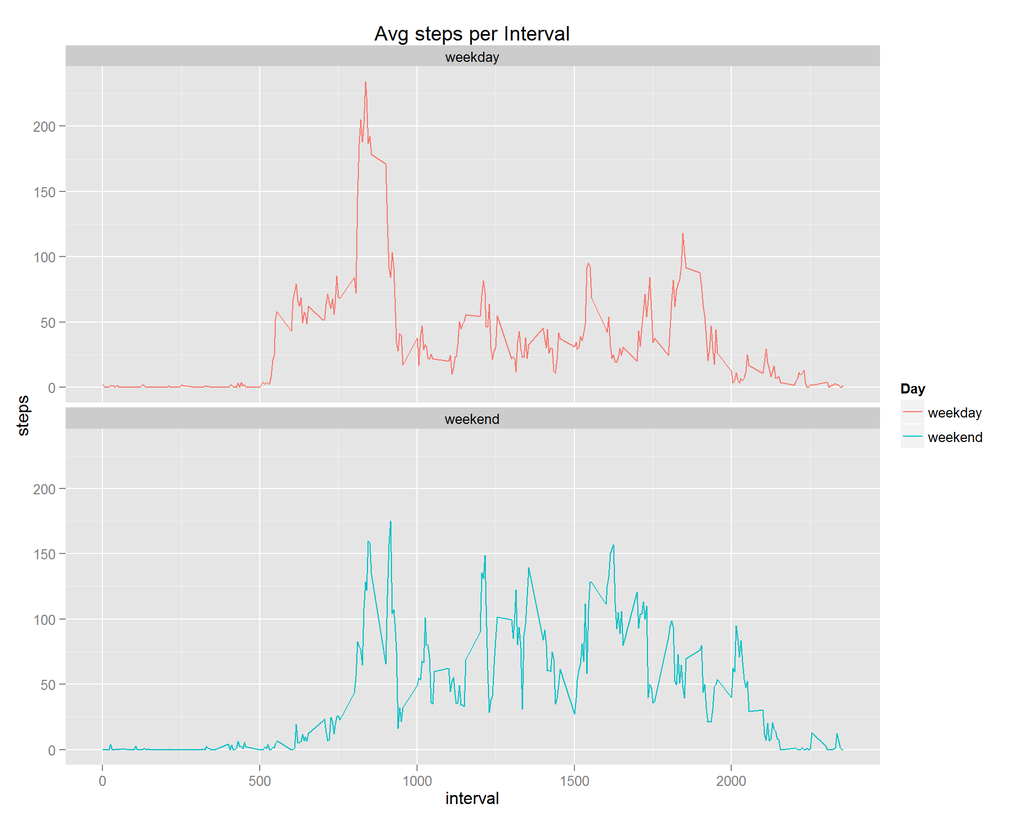

```r
TL2 <- ggplot(interval2, aes(x=interval, y = steps, color = Day)) + geom_line() + facet_wrap(~Day, ncol = 1, nrow = 2)+labs(title="Avg steps per Interval")
TL2
```

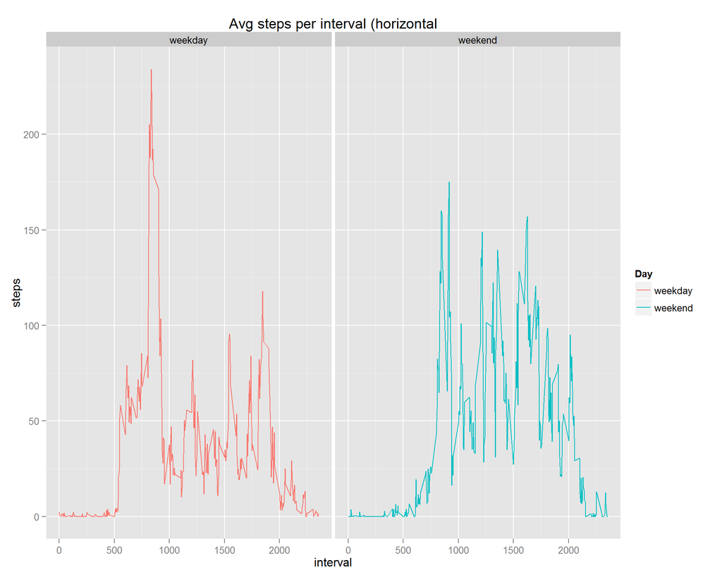

```r
TL2hor <- ggplot(interval2, aes(x=interval, y = steps, color = Day)) + geom_line() + facet_wrap(~Day, ncol = 2, nrow = 1)+labs(title="Avg steps per interval (horizontal")
TL2hor
```

**Conclusion**

At first glance, one can arrive to the conclusion that the number of steps whithin the intervals between 500 and 1000, is bigger than those in weekends. Nevertheless, the mean for weekends is larger than the former and, considering that only about 4 thousand records correspond to weekends, we could think now that the number of steps is larger on weekends. This could have somethig to do with some cultural factors that could determine the type of activities a person do in weekends or in weekdays.

```r
comparison <- days%>%
            group_by(Day)%>%
            summarise(steps = mean(steps))%>%
      print()
```

```
## Source: local data frame [2 x 2]
##
##       Day    steps
## 1 weekday 35.33796
## 2 weekend 43.07837
```